# Covid Project Group 1: Hospitalization Rate Vs. Case Fatality Ratio

Nick Schaap, Stephen Duffy, Chris Emm

## 0.1 Data Processing (Nick Schapp)

# 1 See csv file

## 1.1 Data visualization (Stephen Duffy)

```r
data = read.csv("covid_data_group1.csv");
```

# 2 Get state abbreviations represented in data

```r
state_abbr <- function() {
  abbreviations <- c();

  for(i in 1:nrow(data)) {
    abbreviations <- append(abbreviations, data[i,2]);
  }

  return(unique(abbreviations))
}

states <- state_abbr();
```

# 3 Read data by state and clean input

```r
data_by_state <- function(tgt_state) {
  dat <- c();
  pos <- c();
  hos <- c();
  dea <- c();
  flag = 0;

  for(i in 1:nrow(data)) {
    if(is.na(data[i, 1]) || is.na(data[i, 2]) || is.na(data[i, 3]) || is.na(data[i, 4]) || is.na(data[i, 5])) {
      next;
    }

    date_str = data[i,1];
    clean_date <- paste(substr(date_str, 0, 4), substr(date_str, 5, 6), substr(date_str, 7, 8), sep="-");

    state = data[i, 2];
    positive = strtoi(data[i, 3]);
    hospitalized = strtoi(data[i, 4]);
    deaths = strtoi(data[i, 5]);

    if (all(state == tgt_state)) {
      flag = 1;
      dat <- append(dat, clean_date);
      pos <- append(pos, positive);
      hos <- append(hos, hospitalized);
      dea <- append(dea, deaths);
    }
    else {
      if(flag == 1) { break; } else { next; }
    }
  }

  out <- data.frame(
    dates = as.Date(dat),
    positives = pos,
    hospitalized = hos,
    deaths = dea
  );

  # reorder so dates are in ascending order
  sorted_out <- out[order(out$dates),]

  return(sorted_out);
}
```

# 4 Plot the ratio for each given region.

```r
plot_region <- function(regional_states) {
  first_data = data_by_state(regional_states[2]);

  x <- first_data[,3]
  y <- first_data[,4]

  plot(x,
       y,
       type = "p",
       lwd = 2,
       col = "#000000",
       xlab = "Hospitalizations",
       ylab = "Deaths",
       main = regional_states[1])

  colors <- c("#000000");

  if(length(regional_states) == 1) {
    return();
  }

  for(state in regional_states) {
    if(nchar(state) > 2 ) { next; }
    color_new <- rgb(runif(5),runif(5),runif(5));
    colors <- append(colors, color_new);
    print(paste("Plotting ", state));
    data_here <- data_by_state(state);

    # NOTE HERE DATA COULD BE INVALID
    if(is.null(dim(data_here)) || dim(data_here) < 4) { print(paste("Plotting failed due to missing data for:", state)); next; }

    #try(lines(data_here[,3], data_here[,4], type = "l", lwd = 2, col=color_new))
    color_new = "";
  }

  # Adds line for correlation coefficient to our plot
  mod = lm(y~x)
  abline(mod$coefficients[1],mod$coefficients[2], col = 'purple') #Extract slope and intercept from output of lm

  # Print correlation coefficient of the region
  print(paste(regional_states[1], " correlation between hospitalizations and deaths: ", cor(x,y)))

  #legend("right", legend=states, col=colors);
}
```

# 5 Plot by region and place into nice grid

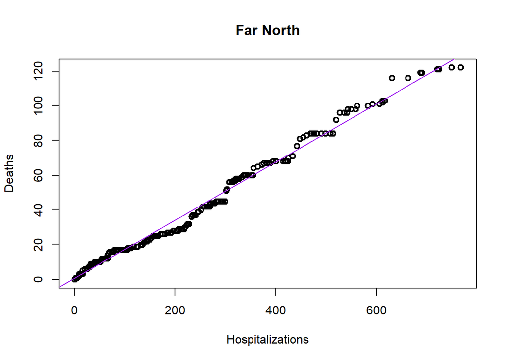

```
## [1] "Plotting  AK"
## [1] "Far North  correlation between hospitalizations and deaths:  0.995636769063713"
```

```r
fn <- c("Far North", "AK");
ne <- c("North East", "CT", "IA", "IL", "IN", "KS", "MA", "ME", "MI", "MN", "MO", "ND", "NE",
        "NH", "NJ", "NY", "OH", "PA", "RI", "SD", "VA", "VT", "WI", "WV");
nw <- c("North West", "CO", "ID", "MT", "ND", "NE", "NV", "OR", "SD", "UT", "WA", "WY");
se <- c("South East", "AL", "AR", "DE", "FL", "GA", "IL", "KS", "KY", "LA", "MD", "MO", "MS",
        "NC", "OK", "SC", "TN", "TX");
sw <- c("South West", "AZ", "CA", "NM", "NV", "OK", "TX");

plot_region(fn);
```

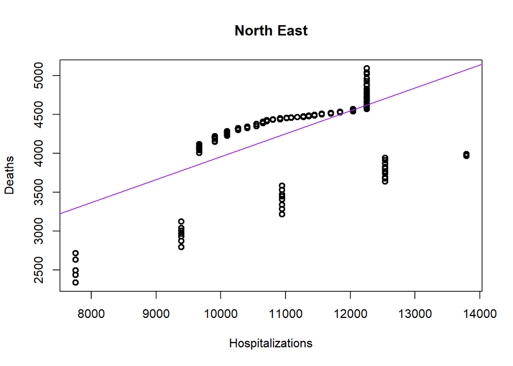

```
## [1] "Plotting  CT"
## [1] "Plotting  IA"
## [1] "Plotting  IL"
## [1] "Plotting failed due to missing data for: IL"
## [1] "Plotting  IN"
## [1] "Plotting  KS"
## [1] "Plotting  MA"
## [1] "Plotting  ME"
## [1] "Plotting  MI"
## [1] "Plotting failed due to missing data for: MI"
## [1] "Plotting  MN"
## [1] "Plotting  MO"
## [1] "Plotting failed due to missing data for: MO"
## [1] "Plotting  ND"
## [1] "Plotting  NE"
## [1] "Plotting  NH"
## [1] "Plotting  NJ"
## [1] "Plotting  NY"
## [1] "Plotting  OH"
## [1] "Plotting  PA"
## [1] "Plotting  RI"
## [1] "Plotting  SD"
## [1] "Plotting  VA"
## [1] "Plotting  VT"
## [1] "Plotting  WI"
## [1] "Plotting  WV"
## [1] "North East  correlation between hospitalizations and deaths:  0.624749843439957"
```

```r
plot_region(ne);
```

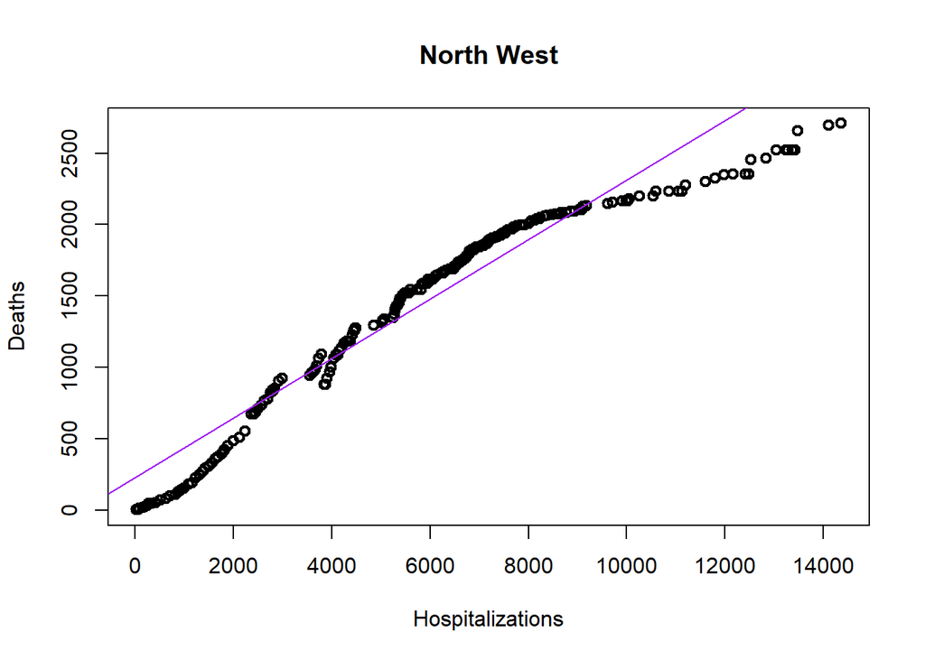

```
## [1] "Plotting  CO"
## [1] "Plotting  ID"
## [1] "Plotting  MT"
## [1] "Plotting  ND"
## [1] "Plotting  NE"
## [1] "Plotting  NV"
## [1] "Plotting failed due to missing data for: NV"
## [1] "Plotting  OR"
## [1] "Plotting  SD"
## [1] "Plotting  UT"
## [1] "Plotting  WA"
## [1] "Plotting  WY"
## [1] "North West  correlation between hospitalizations and deaths:  0.963956835015615"
```

```r
plot_region(nw);
```

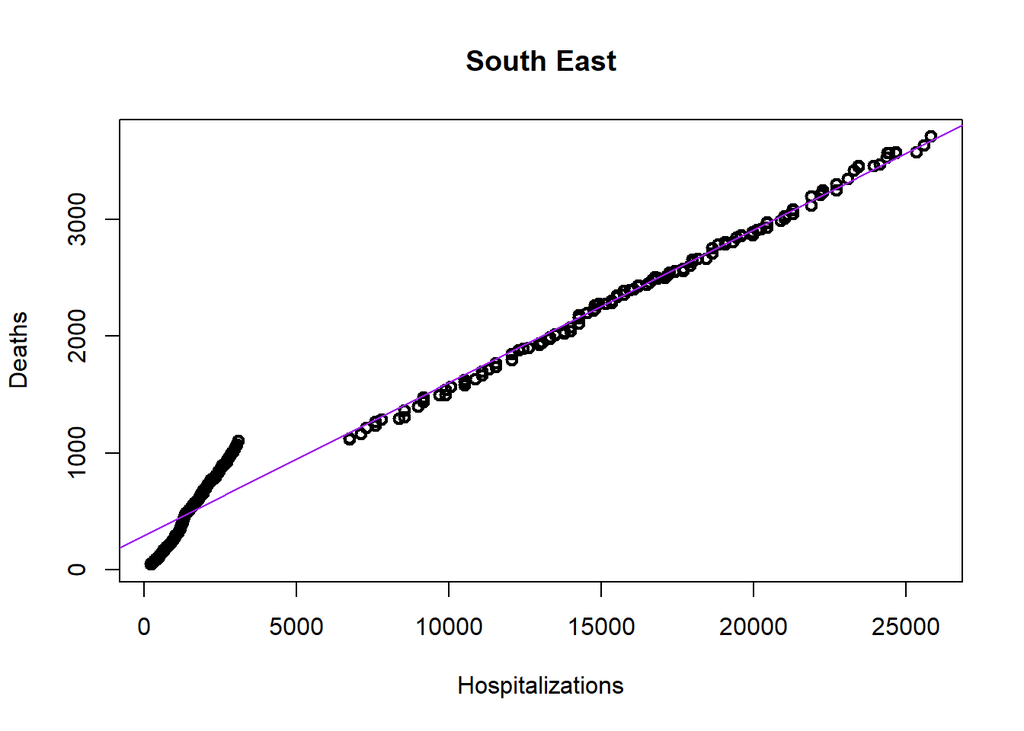

```
## [1] "Plotting  AL"
## [1] "Plotting  AR"
## [1] "Plotting  DE"
## [1] "Plotting failed due to missing data for: DE"
## [1] "Plotting  FL"
## [1] "Plotting  GA"
## [1] "Plotting  IL"
## [1] "Plotting failed due to missing data for: IL"
## [1] "Plotting  KS"
## [1] "Plotting  KY"
## [1] "Plotting  LA"
## [1] "Plotting failed due to missing data for: LA"
## [1] "Plotting  MD"
## [1] "Plotting  MO"
## [1] "Plotting failed due to missing data for: MO"
## [1] "Plotting  MS"
## [1] "Plotting  NC"
## [1] "Plotting failed due to missing data for: NC"
## [1] "Plotting  OK"
## [1] "Plotting  SC"
## [1] "Plotting  TN"
## [1] "Plotting  TX"
## [1] "Plotting failed due to missing data for: TX"
## [1] "South East  correlation between hospitalizations and deaths:  0.992256004818395"
```

```r
plot_region(se);
```

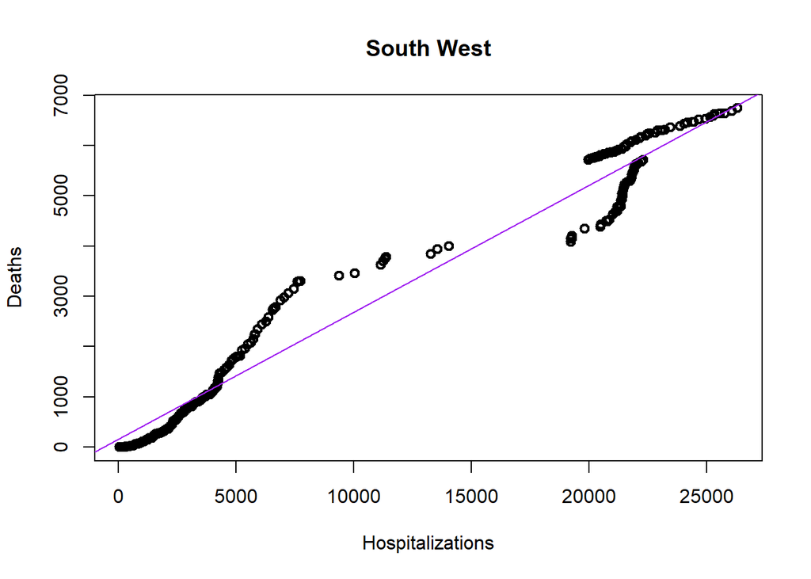

```
## [1] "Plotting  AZ"
## [1] "Plotting  CA"
## [1] "Plotting failed due to missing data for: CA"
## [1] "Plotting  NM"
## [1] "Plotting  NV"
## [1] "Plotting failed due to missing data for: NV"
## [1] "Plotting  OK"
## [1] "Plotting  TX"
## [1] "Plotting failed due to missing data for: TX"
## [1] "South West  correlation between hospitalizations and deaths:  0.982338155758964"
```

```r
plot_region(sw);
```

## 5.1 Date Analysis (Chris Emm)

- Correlation by Region:
  - Far North:
    - Correlation coefficient is 0.995636769063713, so there is very strong, positive correlation between the increase in hospitalizations and the increase of deaths.
    - Regression line on the plot is very strong in relation to the points plotted on the graph.This shows that there is likely a strong relationship between the two variables.
  - North East:
    - Correlation coefficient is 0.624749843439957, so there is a relatively weak, positive correlation between the increase in hospitalizations and the increase of deaths.This doesn’t mean that there is no relationship, but with the data that is reported we could likely presume that if someone is sent to the hospital for Covid-19 in the North East, it is not necessarily predicted that they will die.This could still be attributed to lack of data being reported too.
    - Regression line on the plot is very weak in relation to the points plotted on the graph.This shows that there is likely a weak relationship between the two variables.
  - North West:
    - Correlation coefficient is 0.963956835015615, so there is very strong, positive correlation between the increase in hospitalizations and the increase of deaths.
    - It appears that as hospitalizations increase towards the very end of the graph (10,000+ hospitalizations), that the deaths have a little dip. This is interesting becasue u would think that it might be harder to save some lives if all the hospital beds are taken up, but it appears that there could be a slight drop.
    - Regression line on the plot is very strong in relation to the points plotted on the graph.This shows that there is likely a strong relationship between the two variables.
  - South East:
    - Correlation coefficient is 0.992256004818395, so there is very strong, positive correlation between the increase in hospitalizations and the increase of deaths.
    - It appears that as hospitalizations increase, the deaths increase linearly along with them.This is visible when looking at the plot with its points nearly on top of the regression line.
    - Regression line on the plot is very strong in relation to the points plotted on the graph.This shows that there is likely a strong relationship between the two variables. There is a few abnormalities that could likely be outliers that are effecting the plot at the very beginning of the graph,as those points are the only ones not practically on top of the regression line.
  - South West:
    - Correlation coefficient is 0.982338155758964, so there is very strong, positive correlation between the increase in hospitalizations and the increase of deaths.
    - There appear to be a lot of data stacked on top of each other, as the lines at the beginning and end of the plot are thicker than the rest. This makes it so that we don’t see much data in the middle area of hospitalizations/deaths. Because of this, it appears that a lot of states have either low hospitalizations/low deaths, or high hospitalizations/high deaths.
    - Regression line on the plot appears to be fairly strong for the majority of the data. There are some data that may or may not be outliers based off of how far they are off the regression line, however the majority of the data is relatively close to the line and thus it appears that there is a somewhat strong relationship (as the corr coeff. tells us)
- Overall:
- 4 of the 5 regions that week looked at appeared to have a strong correlation between hospitalizations and deaths. After analyzing the data we collected, it brings forth some questions.
1. How accurate is the data in terms of is enough data being reported so that some outliers aren’t affecting the results too much?
2. The North East had a relatively weak correlation. Possible reasons?
   1. Some states might have people that come in even if they don’t actually need to be nursed back to help?
   2. States with high hospitalizations seem to have the “best hospitals” (3 of top 5 hospitals in US are in the North East)
      - Mayo Clinic -> MN
      - Cleaveland Clinic -> OH
      - Massachusetts General Hospital -> MA
   - This is likely becasue high hospitalization rates are in large cities and large cities tend to have better hospitals
   - So, maybe these "better hospitals give better care and have more capacity (which is more care), and thus less people die?
- Other than that, overall it seems that there is a significant correlation between the hospitalization rates and the death rates for people who have gotten Covid-19.